# Do chatbots sound equally sure in French and in Arabic?

A small audit of expressed certainty in ChatGPT and Gemini

Author

Houda Es-sqalli

Published

October 3, 2026

# Why this audit

When people ask a chatbot about health or public services, the answer can sound sure or cautious. That tone may shape whether they check it before passing it on. Before asking that question about people, I wanted to know what certainty cues users actually meet, and whether they differ by language. This is a first, small look: 10 questions, 2 languages, 2 chatbots, 40 answers.

It is a small study. The point is to test the pipeline and the lexicon, not to draw conclusions about the chatbots.

```r
library(dplyr)
library(tidyr)
library(readr)
library(ggplot2)
library(knitr)

source("R/score_certainty.R")
dir.create("output", showWarnings = FALSE)
```

# Data

The 10 questions cover public health (HPV vaccine, antibiotics and flu, measles vaccination, a COVID-19 myth, fever in infants) and public services in Morocco (ID card renewal, passport validity, AMO Tadamon, birth certificates online, direct social aid). Each one has an answer that can be checked against an official source.

Every question was asked once, in French and in Modern Standard Arabic, to ChatGPT and to Gemini, on 3 October 2026. Each question was asked in a new conversation, with no follow-up, and both chatbots were used without an account so that no memory or personalisation could carry over between questions. Logged out, Gemini runs its Flash-Lite model; ChatGPT does not display which model it uses.

```r
responses <- read_csv("data/responses.csv", show_col_types = FALSE)
lexicon   <- read_csv("data/lexicon.csv",   show_col_types = FALSE)

responses |>
  count(chatbot, language) |>
  kable(caption = "Answers collected per chatbot and language")
```

Answers collected per chatbot and language

| chatbot | language | n |
| --- | --- | --- |
| ChatGPT | AR | 10 |
| ChatGPT | FR | 10 |
| Gemini | AR | 10 |
| Gemini | FR | 10 |

# Method

## Lexicon

Certainty is measured with a small bilingual lexicon of hedges and boosters, following Hyland’s (2005) categories. The French and Arabic lists were built from common markers in each language and checked against the answers. They are kept in `data/lexicon.csv` so anyone can see exactly what is counted, and change it. Version 1 of the lexicon was fixed before any validation; version 2 adds the terms that the validation check showed were missing (see below).

- **Hedges** lower commitment: *peut, généralement, environ, le cas échéant* / *قد + verb, عادة, غالبا, يمكن, تختلف*.
- **Boosters** raise it: *jamais, uniquement, aucun, seules* / *أبدا, فقط, حصريا, الوحيدة*.
- **Evidence** markers point to a source: *selon le, OMS, ministère, officiel* / *وفق, وزارة, منظمة الصحة العالمية*.
- **Verify** prompts tell the user to check: *vérifier* / *التأكد*.

A few choices matter:

- *قد* is only a hedge before an imperfect verb (*قد يصف*, “may prescribe”). Before a past verb it means the opposite (“indeed”), so the pattern requires a following ي, ت or ن.
- After diacritics are removed, *أبدًا* (“never”) and *ابدأ* (“start”) become the same string. “Never” is only counted at the end of a clause.
- Deontic markers (*il faut*, *يجب*) are left out. They tell the user what to do, not how sure the chatbot is.
- *Peut* and *يمكن* are counted, but they do not always signal doubt. They also express permission or ability (“qui peut l’avoir”, “يمكن طلب الوثيقة”). Second-person forms (*vous pouvez*, *يمكنك*) are not in the lexicon, but a few third-person cases of this kind remain: 6 of the 15 French matches and 2 of the 3 Arabic ones. Because the French count is larger, this could inflate French hedging, so the robustness check below also drops modal verbs altogether.

## Measures

For each answer: word count, number of hedges, boosters, evidence markers and verify prompts, whether it opens with a flat *Oui/Non* (*نعم/لا*), and a **certainty index** = (boosters − hedges) per 100 words. Rates are per 100 words because Gemini writes longer answers. The last column, `web_sources`, records whether the chatbot displayed links to web sources under its answer (noted at collection, not computed).

```r
scored <- score_certainty(responses, lexicon, lex_version = 1)

write_csv(scored, "output/scored_responses.csv")
```

# Results

## Overview

```r
summary_tab <- scored |>
  group_by(chatbot, language) |>
  summarise(
    words          = mean(n_words),
    hedges_100     = mean(hedges_100),
    boosters_100   = mean(boosters_100),
    evidence_100   = mean(evidence_100),
    certainty      = mean(certainty_index),
    flat_opening   = sum(categorical_opener),
    web_sources    = sum(web_sources == "yes"),
    .groups = "drop"
  )

summary_tab |>
  kable(digits = 2,
        col.names = c("Chatbot", "Language", "Words", "Hedges /100w",
                      "Boosters /100w", "Evidence /100w", "Certainty index",
                      "Flat Oui/Non (of 10)", "Web sources (of 10)"))
```

| Chatbot | Language | Words | Hedges /100w | Boosters /100w | Evidence /100w | Certainty index | Flat Oui/Non (of 10) | Web sources (of 10) |
| --- | --- | --- | --- | --- | --- | --- | --- | --- |
| ChatGPT | AR | 127.3 | 1.03 | 0.00 | 1.57 | -1.03 | 4 | 8 |
| ChatGPT | FR | 146.9 | 1.85 | 0.00 | 0.75 | -1.85 | 3 | 8 |
| Gemini | AR | 161.5 | 0.31 | 0.54 | 0.93 | 0.23 | 3 | 7 |
| Gemini | FR | 173.8 | 0.71 | 0.83 | 1.12 | 0.11 | 3 | 8 |

## Certainty by language

Each dot is one answer; the black mark is the mean.

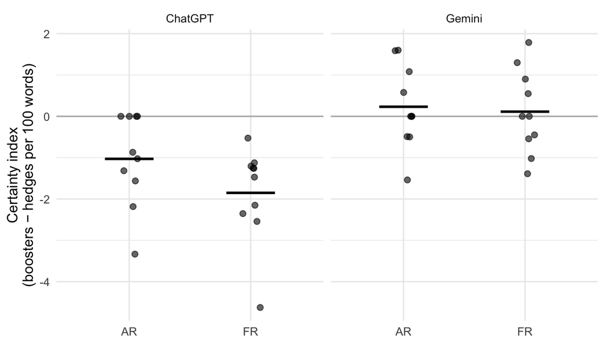

```r
ggplot(scored, aes(x = language, y = certainty_index)) +
  geom_hline(yintercept = 0, colour = "grey70") +
  geom_jitter(width = 0.08, height = 0, alpha = 0.6, size = 2) +
  stat_summary(fun = mean, geom = "crossbar", width = 0.4, linewidth = 0.4) +
  facet_wrap(~ chatbot) +
  labs(x = NULL,
       y = "Certainty index\n(boosters − hedges per 100 words)") +
  theme_minimal(base_size = 12)
```

## Same question, two languages

The fairest comparison holds the question constant: for each chatbot and question, how does the French answer compare with the Arabic one?

```r
paired <- scored |>
  select(chatbot, question_id, language, certainty_index, hedges_100) |>
  pivot_wider(names_from = language,
              values_from = c(certainty_index, hedges_100)) |>
  mutate(diff_certainty = certainty_index_AR - certainty_index_FR,
         diff_hedges    = hedges_100_AR - hedges_100_FR)

paired |>
  group_by(chatbot) |>
  summarise(
    mean_diff_certainty = mean(diff_certainty),
    arabic_more_certain = sum(diff_certainty > 0),
    ties                = sum(diff_certainty == 0),
    arabic_less_certain = sum(diff_certainty < 0)
  ) |>
  kable(digits = 2,
        col.names = c("Chatbot", "Mean difference (AR − FR)",
                      "AR more certain", "Ties", "AR less certain"))
```

| Chatbot | Mean difference (AR − FR) | AR more certain | Ties | AR less certain |
| --- | --- | --- | --- | --- |
| ChatGPT | 0.82 | 8 | 0 | 2 |
| Gemini | 0.12 | 5 | 1 | 4 |

# Checking the lexicon

The lexicon only counts words; it does not understand them. To see what it misses, a random subsample of 10 answers (drawn from all four chatbot × language cells) was coded a second time, line by line, with the codebook below.

This second coding was model-assisted. The codes are kept in `data/validation_coded.csv` with the exact words counted, so each decision can be checked. They are a first check on the lexicon, not a gold standard; independent human coding is the next step.

**Codebook.** A *hedge* is any expression that lowers the writer’s commitment to a claim (possibility, approximation, frequency, a claim marked as time-bound or partial). A *booster* is any expression that closes down alternatives (absolutes, exclusivity, emphatic negation). Deontic phrases (*il faut*, *يجب*) are not coded. The overall rating goes from 1 (very cautious throughout) to 5 (categorical, no caveat).

The subsample was drawn once with `set.seed(2027)`: three answers per chatbot × language cell, then 10 of those 12 at random. Random draws can change across `dplyr` versions, so the drawn IDs are saved in `data/validation_ids.csv` and read from there.

```r
validation_ids <- read_csv("data/validation_ids.csv",
                           show_col_types = FALSE)$id

validation <- read_csv("data/validation_coded.csv", show_col_types = FALSE) |>
  left_join(scored |> select(id, chatbot, language,
                             lex_hedges = hedges, lex_boosters = boosters,
                             certainty_index),
            by = "id")

# The coded file should match the sample drawn above.
stopifnot(setequal(validation$id, validation_ids))

validation |>
  select(id, chatbot, language, lex_hedges, hedges,
         lex_boosters, boosters, certainty_index, certainty_1to5) |>
  kable(digits = 2,
        col.names = c("ID", "Chatbot", "Lang.", "Hedges (lexicon)",
                      "Hedges (coder)", "Boosters (lexicon)",
                      "Boosters (coder)", "Certainty index", "Rating 1-5"))
```

| ID | Chatbot | Lang. | Hedges (lexicon) | Hedges (coder) | Boosters (lexicon) | Boosters (coder) | Certainty index | Rating 1-5 |
| --- | --- | --- | --- | --- | --- | --- | --- | --- |
| R20 | ChatGPT | AR | 2 | 2 | 0 | 0 | -1.56 | 4 |
| R31 | Gemini | AR | 0 | 1 | 0 | 1 | 0.00 | 4 |
| R17 | ChatGPT | AR | 0 | 1 | 0 | 1 | 0.00 | 4 |
| R18 | ChatGPT | AR | 0 | 2 | 0 | 0 | 0.00 | 3 |
| R07 | ChatGPT | FR | 1 | 2 | 0 | 1 | -1.47 | 4 |
| R24 | Gemini | FR | 3 | 2 | 6 | 6 | 1.30 | 5 |
| R30 | Gemini | FR | 1 | 0 | 0 | 0 | -0.54 | 5 |
| R38 | Gemini | AR | 0 | 0 | 1 | 2 | 0.58 | 5 |
| R08 | ChatGPT | FR | 2 | 5 | 0 | 0 | -1.20 | 3 |
| R26 | Gemini | FR | 2 | 2 | 1 | 1 | -0.45 | 4 |

```r
agreement <- tibble(
  measure = c("Hedges found by lexicon / by coder",
              "Boosters found by lexicon / by coder",
              "Correlation of hedge counts (Pearson)",
              "Correlation of booster counts (Pearson)",
              "Certainty index vs overall rating (Spearman)"),
  value = c(
    paste(sum(validation$lex_hedges), "/", sum(validation$hedges)),
    paste(sum(validation$lex_boosters), "/", sum(validation$boosters)),
    sprintf("%.2f", cor(validation$lex_hedges, validation$hedges)),
    sprintf("%.2f", cor(validation$lex_boosters, validation$boosters)),
    sprintf("%.2f", cor(validation$certainty_index, validation$certainty_1to5,
                        method = "spearman"))
  )
)

kable(agreement, col.names = c("", ""))
```

| Hedges found by lexicon / by coder | 11 / 17 |
| --- | --- |
| Boosters found by lexicon / by coder | 8 / 12 |
| Correlation of hedge counts (Pearson) | 0.52 |
| Correlation of booster counts (Pearson) | 0.96 |
| Certainty index vs overall rating (Spearman) | 0.39 |

Boosters are picked up well. Hedges are not: the lexicon misses about a third of them, mostly approximators and qualifiers such as *principalement, notamment, actuellement, près de* and *أساسًا، بصفة عامة، حتى الآن*. The weak link between the index and the overall rating also shows that a confident tone often comes from the content (a list of exact amounts with no source) rather than from particular words. That is a limit of any word list, and a reason to pair it with human or model-based coding in the full study.

## Does the result survive a better lexicon?

Two checks. Version 2 adds the missing hedges; because those terms were chosen after looking at the validation sample, it is a robustness check, not a replacement. The second check goes the other way: it removes the modal verbs (*peut* and *يمكن* rows) from version 1, the strictest test of whether non-doubt uses of these verbs drive the gap.

```r
scored_v2 <- score_certainty(responses, lexicon, lex_version = 2)

lexicon_no_modal <- lexicon |>
  filter(!(category == "hedge" & str_detect(pattern, "^(peut|يمكن)")))
scored_no_modal <- score_certainty(responses, lexicon_no_modal, lex_version = 1)

bind_rows(
  scored          |> mutate(lexicon = "v1"),
  scored_v2       |> mutate(lexicon = "v2"),
  scored_no_modal |> mutate(lexicon = "no_modal")
) |>
  group_by(lexicon, chatbot, language) |>
  summarise(hedges_100 = mean(hedges_100), .groups = "drop") |>
  pivot_wider(names_from = lexicon, values_from = hedges_100) |>
  select(chatbot, language, v1, v2, no_modal) |>
  kable(digits = 2,
        col.names = c("Chatbot", "Language", "Hedges /100w (v1)",
                      "Hedges /100w (v2)", "Hedges /100w (v1, no modals)"))
```

| Chatbot | Language | Hedges /100w (v1) | Hedges /100w (v2) | Hedges /100w (v1, no modals) |
| --- | --- | --- | --- | --- |
| ChatGPT | AR | 1.03 | 1.35 | 0.77 |
| ChatGPT | FR | 1.85 | 2.72 | 1.04 |
| Gemini | AR | 0.31 | 0.44 | 0.31 |
| Gemini | FR | 0.71 | 0.88 | 0.51 |

In all three versions, both chatbots hedge less in Arabic than in French, and ChatGPT hedges more than Gemini. Without modal verbs the gap is smaller, so part of it comes from *peut*, but it does not disappear.

# Limitations

- 10 questions and one run each. Answers change between runs, so a real audit needs repeated runs per question.
- The Arabic lexicon is shorter than the French one. Part of any French–Arabic gap could come from the lexicon, not from the chatbots. The validation and version 2 reduce this risk but do not remove it.
- Rates per 100 words are not neutral across the two languages. Arabic attaches articles, prepositions and conjunctions to the next word, so the same content takes fewer words. This raises Arabic rates and works against the gap found here, but a per-sentence measure would be fairer.
- The second coding was model-assisted. Independent human coding, ideally two coders per language, is needed before any claim goes beyond this first look.
- A word list misses certainty carried by structure (lists of steps, bold text, a flat “Non.” on its own line). The flat-opening variable only partly covers this.
- Both chatbots were used without an account, which matches what many users see but not what paying users get.

# Reference

Hyland, K. (2005). *Metadiscourse: Exploring interaction in writing*. Continuum.